# Consulta TP Series de Tiempo: transformación de la serie y modelos

María Inés Cañizares

10/11/2026

# 1. Datos

Muertes mensuales por ACV en Estados Unidos (CDC WONDER). Se ajusta con enero de 1999 a diciembre de 2018 y se reservan los 12 meses de 2019 para evaluar pronósticos.

```r
datos <- read.delim("Multiple_Cause_of_Death__1999-2020.xls", sep = "\t") |>
  mutate(Month = yearmonth(`Month.Code`)) |>
  select(Month, muertes = Deaths) |>
  as_tsibble(index = Month)

datos_filtrado <- datos |> filter_index("1999 Jan" ~ "2018 Dec")
datos_test     <- datos |> filter_index("2019 Jan" ~ "2019 Dec")
```

# 2. Series transformadas

Se comparan tres versiones de la serie:

- **Original:** sin transformar.
- **Logaritmo.**
- **Box-Cox con λ = −1:** vale $1 - 1/y$, es decir la transformación recíproca.

```r
niveles <- c("Original", "Logaritmo", "BoxCox")

datos_trans <- datos_filtrado |>
  mutate(
    Original  = muertes,
    Logaritmo = log(muertes),
    BoxCox    = box_cox(muertes, -1)
  )
```

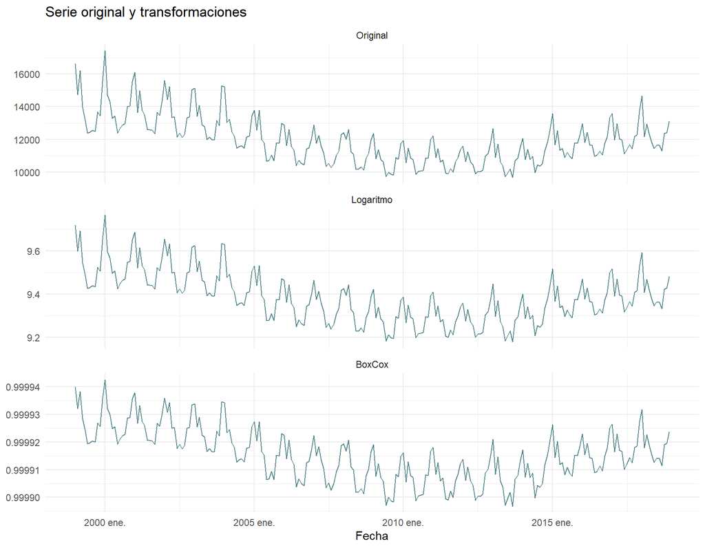

```r
datos_trans |>
  as_tibble() |>
  pivot_longer(all_of(niveles), names_to = "serie", values_to = "valor") |>
  mutate(serie = factor(serie, levels = niveles)) |>
  ggplot(aes(x = Month, y = valor)) +
  geom_line(color = "cadetblue4") +
  facet_wrap(~ serie, ncol = 1, scales = "free_y") +
  labs(x = "Fecha", y = NULL,
       title = "Serie original y transformaciones") +
  theme_minimal()
```

# 3. ¿La variabilidad depende del nivel?

## Diagramas de caja por año

### Serie original

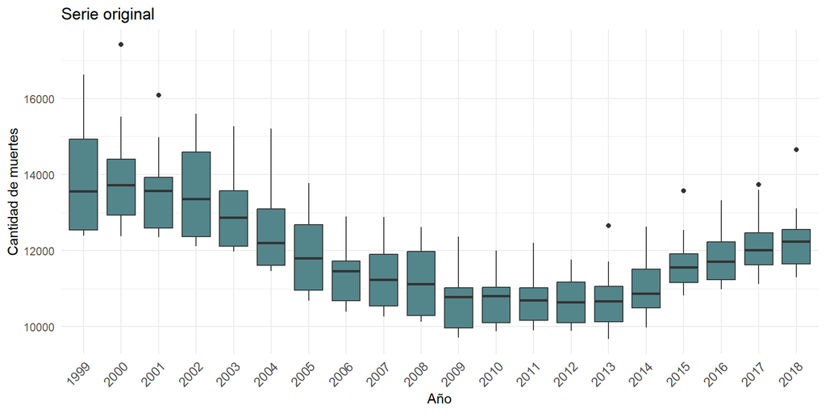

```r
datos_trans |>
  mutate(año = year(Month)) |>
  ggplot(aes(x = as.factor(año), y = Original)) +
  geom_boxplot(fill = "cadetblue4") +
  labs(
    x = "Año",
    y = "Cantidad de muertes",
    title = "Serie original"
  ) +
  theme_minimal() +
  theme(
    axis.text.x = element_text(angle = 45, hjust = 1, size = 10)
  )
```

### Transformación logarítmica

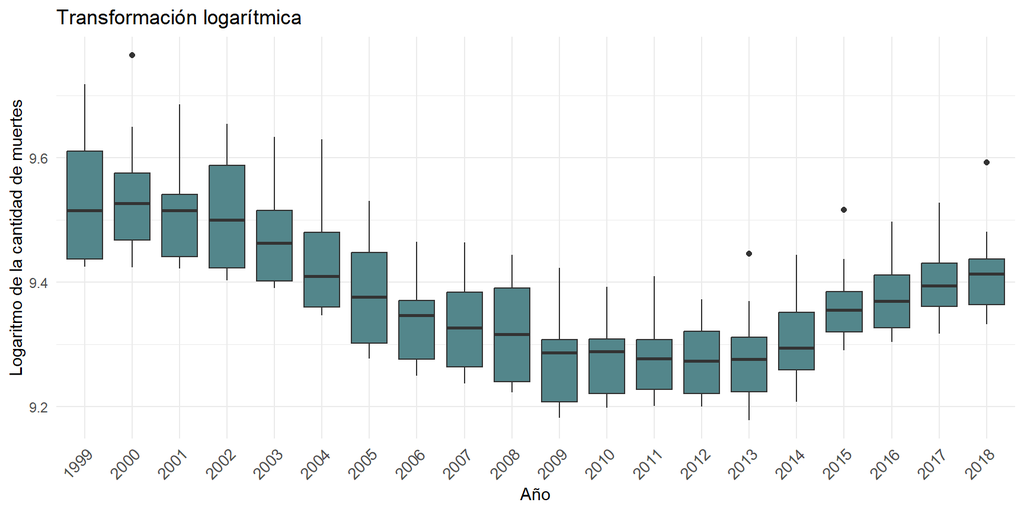

```r
datos_trans |>
  mutate(año = year(Month)) |>
  ggplot(aes(x = as.factor(año), y = Logaritmo)) +
  geom_boxplot(fill = "cadetblue4") +
  labs(
    x = "Año",
    y = "Logaritmo de la cantidad de muertes",
    title = "Transformación logarítmica"
  ) +
  theme_minimal() +
  theme(
    axis.text.x = element_text(angle = 45, hjust = 1, size = 10)
  )
```

### Transformación Box-Cox

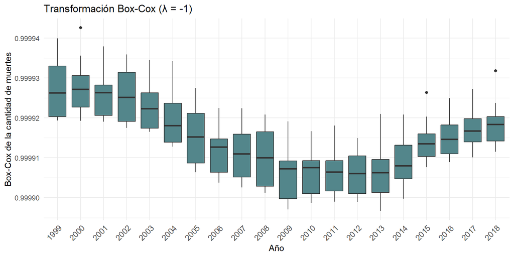

```r
datos_trans |>
  mutate(año = year(Month)) |>
  ggplot(aes(x = as.factor(año), y = BoxCox)) +
  geom_boxplot(fill = "cadetblue4") +
  labs(
    x = "Año",
    y = "Box-Cox de la cantidad de muertes",
    title = "Transformación Box-Cox (λ = -1)"
  ) +
  theme_minimal() +
  theme(
    axis.text.x = element_text(angle = 45, hjust = 1, size = 10)
  )
```

## Media vs. desvío estándar anual

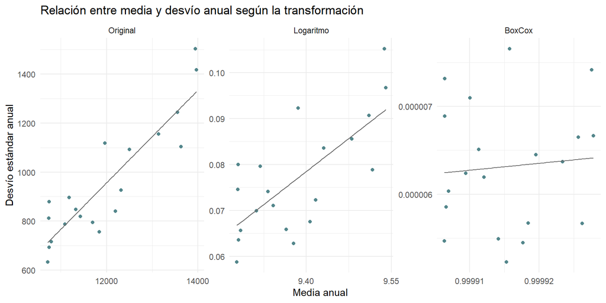

```r
anual <- datos_trans |>
  as_tibble() |>
  mutate(año = year(Month)) |>
  pivot_longer(all_of(niveles), names_to = "serie", values_to = "valor") |>
  mutate(serie = factor(serie, levels = niveles)) |>
  group_by(serie, año) |>
  summarise(media = mean(valor), desvio = sd(valor), .groups = "drop")

ggplot(anual, aes(x = media, y = desvio)) +
  geom_point(color = "cadetblue4") +
  geom_smooth(method = "lm", se = FALSE, color = "gray40", linewidth = 0.5) +
  facet_wrap(~ serie, scales = "free") +
  scale_x_continuous(n.breaks = 3) +
  labs(x = "Media anual", y = "Desvío estándar anual",
       title = "Relación entre media y desvío anual según la transformación") +
  theme_minimal()
```

# 4. FAC y FACP

```r
fac_facp <- function(datos, variable, titulo, diferenciar = FALSE) {
  d <- datos |> mutate(z = {{ variable }})
  if (diferenciar) d <- d |> mutate(z = difference(difference(z, 12), 1))
  d <- d |> filter(!is.na(z))

  p1 <- d |> ACF(z, lag_max = 36) |> autoplot() +
    labs(x = "Rezago (meses)", y = "FAC") + theme_minimal()
  p2 <- d |> PACF(z, lag_max = 36) |> autoplot() +
    labs(x = "Rezago (meses)", y = "FACP") + theme_minimal()

  (p1 | p2) + plot_annotation(title = titulo)
}
```

## Series sin diferenciar

### Original

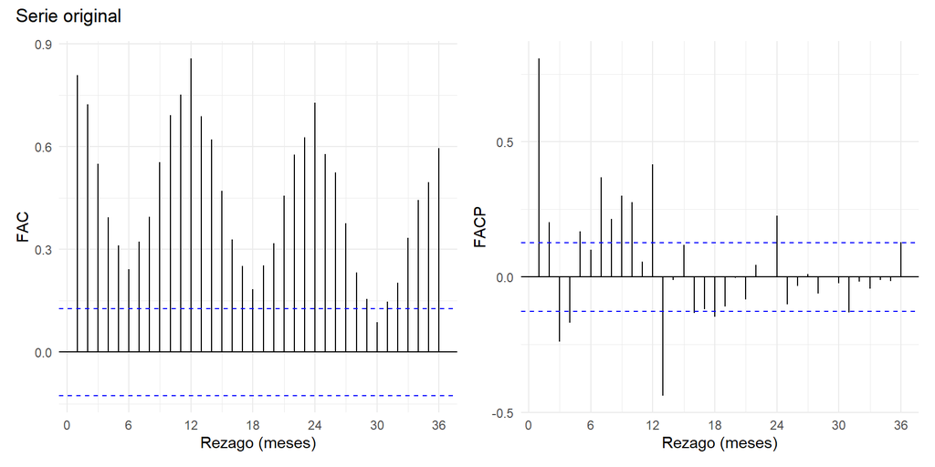

```r
fac_facp(datos_trans, Original, "Serie original")
```

### Logaritmo

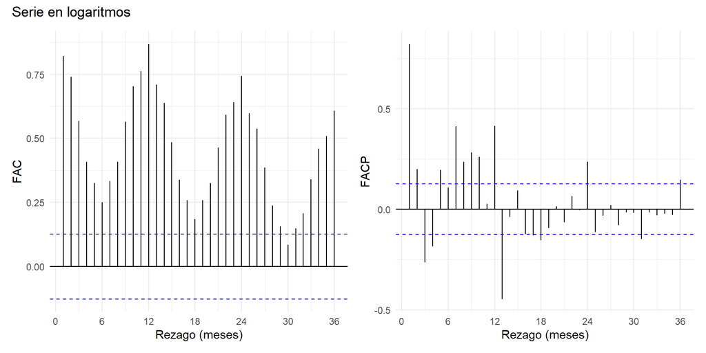

```r
fac_facp(datos_trans, Logaritmo, "Serie en logaritmos")
```

### Box-Cox (λ = −1)

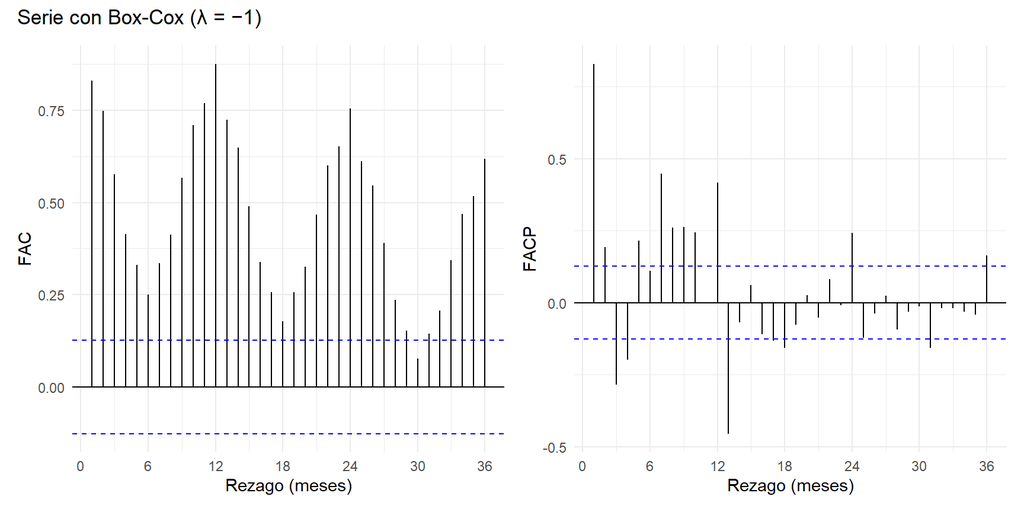

```r
fac_facp(datos_trans, BoxCox, "Serie con Box-Cox (λ = −1)")
```

## Series con una diferencia regular y una estacional

### Original

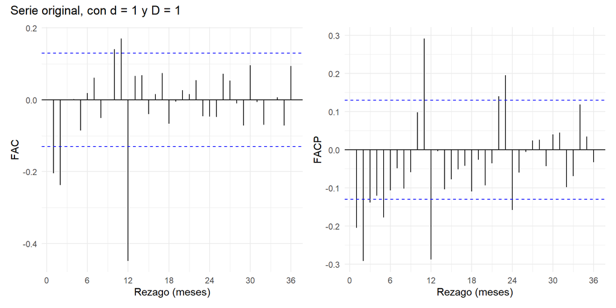

```r
fac_facp(datos_trans, Original, "Serie original, con d = 1 y D = 1", diferenciar = TRUE)
```

### Logaritmo

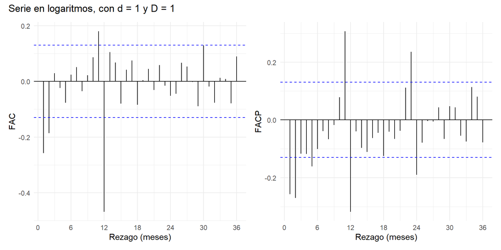

```r
fac_facp(datos_trans, Logaritmo, "Serie en logaritmos, con d = 1 y D = 1", diferenciar = TRUE)
```

### Box-Cox (λ = −1)

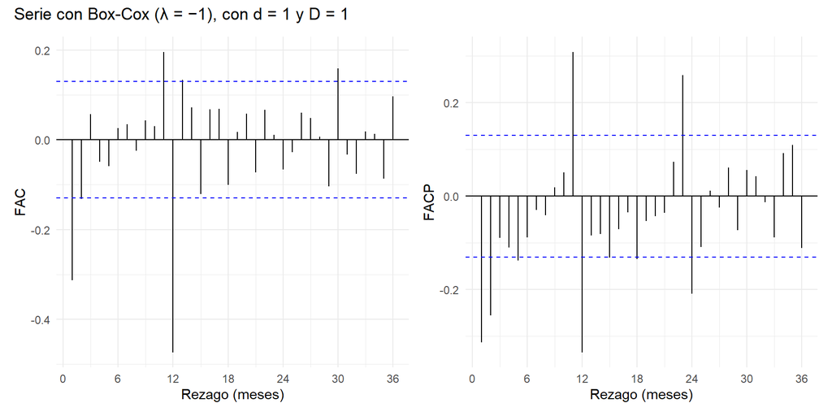

```r
fac_facp(datos_trans, BoxCox, "Serie con Box-Cox (λ = −1), con d = 1 y D = 1", diferenciar = TRUE)
```

# 5. Modelos

Se ajustan los mismos cuatro modelos con cada transformación:

- SARIMA(2,0,0)(2,0,0)[12]
- SARIMA(0,1,1)(0,1,1)[12].
- SARIMA(0,1,2)(0,1,1)[12], variante del anterior.
- SARIMA(0,1,2)(1,1,2)[12], el modelo que eligió el algoritmo automático con la serie original.

```r
fit_orig <- datos_filtrado |>
  model(
    `SARIMA(2,0,0)(2,0,0)` = ARIMA(muertes ~ 1 + pdq(2,0,0) + PDQ(2,0,0)),
    `SARIMA(0,1,1)(0,1,1)` = ARIMA(muertes ~ 0 + pdq(0,1,1) + PDQ(0,1,1)),
    `SARIMA(0,1,2)(0,1,1)` = ARIMA(muertes ~ 0 + pdq(0,1,2) + PDQ(0,1,1)),
    `SARIMA(0,1,2)(1,1,2)` = ARIMA(muertes ~ 0 + pdq(0,1,2) + PDQ(1,1,2))
  )

fit_log <- datos_filtrado |>
  model(
    `SARIMA(2,0,0)(2,0,0)` = ARIMA(log(muertes) ~ 1 + pdq(2,0,0) + PDQ(2,0,0)),
    `SARIMA(0,1,1)(0,1,1)` = ARIMA(log(muertes) ~ 0 + pdq(0,1,1) + PDQ(0,1,1)),
    `SARIMA(0,1,2)(0,1,1)` = ARIMA(log(muertes) ~ 0 + pdq(0,1,2) + PDQ(0,1,1)),
    `SARIMA(0,1,2)(1,1,2)` = ARIMA(log(muertes) ~ 0 + pdq(0,1,2) + PDQ(1,1,2))
  )

fit_bc <- datos_filtrado |>
  model(
    `SARIMA(2,0,0)(2,0,0)` = ARIMA(box_cox(muertes, -1) ~ 1 + pdq(2,0,0) + PDQ(2,0,0)),
    `SARIMA(0,1,1)(0,1,1)` = ARIMA(box_cox(muertes, -1) ~ 0 + pdq(0,1,1) + PDQ(0,1,1)),
    `SARIMA(0,1,2)(0,1,1)` = ARIMA(box_cox(muertes, -1) ~ 0 + pdq(0,1,2) + PDQ(0,1,1)),
    `SARIMA(0,1,2)(1,1,2)` = ARIMA(box_cox(muertes, -1) ~ 0 + pdq(0,1,2) + PDQ(1,1,2))
  )
```

Para cada modelo se calculan:

- **AICc y BIC.**
- **Test de Portmanteau (Ljung-Box)**
- **Test de Shapiro-Wilk**

En los modelos con diferencias se excluyen del diagnóstico los primeros 13 residuos, que dependen de las condiciones iniciales de la diferenciación.

```r
diagnostico <- function(fit, modelo) {
  m <- fit |> select(all_of(modelo))

  # Sin diferencias no se descarta ningún residuo; con d = 1 y D = 1, los primeros 13
  inicio <- if (modelo == "ARIMA(2,0,0)(2,0,0)") yearmonth("1999 Jan") else yearmonth("2000 Feb")

  r   <- augment(m) |> filter(!is.na(.innov), Month >= inicio)
  dof <- tidy(m) |> filter(term != "constant") |> nrow()
  lb  <- function(L) features(r, .innov, ljung_box, lag = L, dof = dof)$lb_pvalue

  tibble(
    Modelo = modelo,
    AICc   = glance(m)$AICc,
    BIC    = glance(m)$BIC,
    `p Ljung-Box (rezago 6)` = lb(6),
    `p Ljung-Box (rezago 12)` = lb(12),
    `p Ljung-Box (rezago 24)` = lb(24),
    `p Shapiro-Wilk` = shapiro.test(r$.innov)$p.value
  )
}

resumen <- function(fit, transformacion) {
  map_df(names(fit), \(m) diagnostico(fit, m)) |>
    mutate(Transformación = transformacion, .before = 1)
}

tabla_modelos <- bind_rows(
  resumen(fit_orig, "Sin transformar"),
  resumen(fit_log,  "Logaritmo"),
  resumen(fit_bc,   "Box-Cox (λ = −1)")
) |>
  mutate(across(starts_with("p "), \(x) format.pval(x, digits = 3, eps = 0.001)))

tabla_modelos |>
  kable(digits = 2, align = "c")
```

| Transformación | Modelo | AICc | BIC | p Ljung-Box (rezago 6) | p Ljung-Box (rezago 12) | p Ljung-Box (rezago 24) | p Shapiro-Wilk |
| --- | --- | --- | --- | --- | --- | --- | --- |
| Sin transformar | SARIMA(2,0,0)(2,0,0) | 3550.36 | 3570.88 | 0.01105 | 0.00298 | < 0.001 | < 0.001 |
| Sin transformar | SARIMA(0,1,1)(0,1,1) | 3304.53 | 3314.70 | < 0.001 | < 0.001 | 0.00695 | < 0.001 |
| Sin transformar | SARIMA(0,1,2)(0,1,1) | 3284.12 | 3297.64 | 0.33721 | 0.51757 | 0.82854 | < 0.001 |
| Sin transformar | SARIMA(0,1,2)(1,1,2) | 3273.52 | 3293.69 | 0.13352 | 0.40147 | 0.88004 | < 0.001 |
| Logaritmo | SARIMA(2,0,0)(2,0,0) | -1006.52 | -985.99 | 0.01267 | 0.00502 | < 0.001 | 0.16956 |
| Logaritmo | SARIMA(0,1,1)(0,1,1) | -1028.15 | -1017.99 | 0.00390 | 0.02785 | 0.28678 | 0.00455 |
| Logaritmo | SARIMA(0,1,2)(0,1,1) | -1038.68 | -1025.16 | 0.60101 | 0.74263 | 0.95992 | 0.00701 |
| Logaritmo | SARIMA(0,1,2)(1,1,2) | -1043.49 | -1023.32 | 0.25286 | 0.73619 | 0.97352 | 0.01013 |
| Box-Cox (λ = −1) | SARIMA(2,0,0)(2,0,0) | -5543.55 | -5523.02 | 0.01585 | 0.00862 | < 0.001 | 0.47229 |
| Box-Cox (λ = −1) | SARIMA(0,1,1)(0,1,1) | -5244.57 | -5234.40 | 0.00885 | < 0.001 | < 0.001 | < 0.001 |
| Box-Cox (λ = −1) | SARIMA(0,1,2)(0,1,1) | -5245.48 | -5231.96 | 0.01329 | < 0.001 | < 0.001 | < 0.001 |
| Box-Cox (λ = −1) | SARIMA(0,1,2)(1,1,2) | -5243.02 | -5222.85 | 0.00166 | < 0.001 | < 0.001 | < 0.001 |

Sobre la significación de los coeficientes

Sin transformar:

- SARIMA(2,0,0)(2,0,0): hay un coef no significativo
- SARIMA(0,1,1)(0,1,1): son significativos
- SARIMA(0,1,2)(0,1,1): son signific
- SARIMA(0,1,2)(1,1,2): son signific

Transformacion logaritmo:

- SARIMA(2,0,0)(2,0,0): hay un coef no significativo
- SARIMA(0,1,1)(0,1,1): son significativos
- SARIMA(0,1,2)(0,1,1): son signific
- SARIMA(0,1,2)(1,1,2): son signific

Transformacion box-cox -1:

- SARIMA(2,0,0)(2,0,0): significativos
- SARIMA(0,1,1)(0,1,1): significativos
- SARIMA(0,1,2)(0,1,1): hay un coef no significativo
- SARIMA(0,1,2)(1,1,2): hay dos coef no significativo